# Stat 323/523: Design and Analysis of Experiments I

Cal Poly - San Luis Obispo, Winter 2024

## Communication

**Dr. Emily Robinson**

Email: erobin17@calpoly.edu

Office: Building 25 Office 103 (by Statistics Department Office)

**Canvas Discussion Board:**

While your posts are not anonymous, in this case there is no such thing as a bad question!

## Course Logistics

**Class Meeting Times:** Tuesday/Thursday

**Room:** Business 003-206

**Office Hours** are held in my office (25-103) during the following times:

[video not shown]

Introducing Faculty Office Hours

| Day | Time |
| --- | --- |
| Monday | 3:10pm - 4:30pm |
| Thursday | 12:30pm - 1:50pm |

Note that office hours are not just for when you have content questions. Stop by to introduce yourself, ask questions about the broader field of statistics, or share what you are working on!

# Course Description

Stat 323/523 is designed to engage you in the principles, construction and analysis of experimental designs. Completely randomized, randomized complete block, Latin squares, Graeco Latin squares, factorial, and nested designs. Fixed and random effects, expected mean squares, multiple comparisons, and analysis of covariance.

**Prerequisites**

Entrance to STAT 323/523 requires completion of STAT 302.

# Learning Objectives

By the end of the course, you should:

- understand the single factor fixed effects model, and be able to carry out the analysis culminating in the F-test and appropriate multiple comparisons.
- understand the difference between fixed and random effects.
- understand the rationale behind the use of blocking, Latin squares, and other noise-reducing designs.
- be able to recognize different designs.
- be able to perform the statistical computations and express the results of the quantitative work through your writing skills.

# Course Materials & Tools

For each topic, you will be provided a set of *course notes* containing definitions, examples, and practice problems. We will work through each set of notes during class time (both as a large class and in groups). You are expected to either print or save the notes to your device and follow along, filling out your set of notes as we go.

Supplemental reading from [A First Course in Design and Analysis of Experiments](http://users.stat.umn.edu/%7Egary/book/fcdae.pdf) by Gary W. Oehlert will be recommended.

Tools and statistical software you will need for this course:

Laptop

Statistical software – R/RStudio or JMP

# Class Schedule & Topic Outline

This schedule is tentative and subject to change.

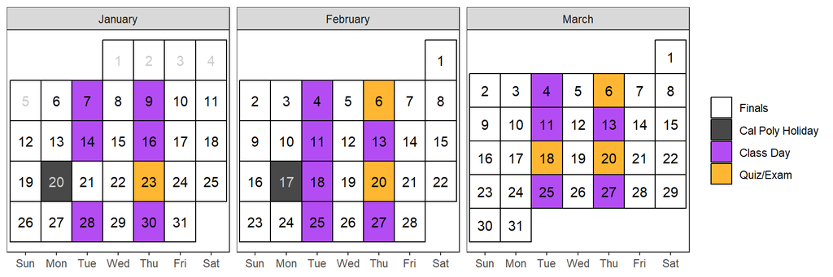

Tentative schedule of class topics:

| Date | Topic |
| --- | --- |
| Jan 7, Jan 9 | Module 1: Intro to DOE |
| Jan 14, Jan 16 | Module 2: CRD |
| Jan 23 | Quiz 1 |
| Jan 28, Jan 30 | Module 3: Power |
| Feb 4 | Module 4: Factorials |
| Feb 6 | Quiz 2 |
| Feb 11, Feb 13 | Module 5: RCBD |
| Feb 18 | Module 5: RCBD |
| Feb 20 | Quiz 3 |
| Feb 25, Feb 27 | Module 6: TBD |
| Mar 4 | Module 7: TBD |
| Mar 6 | Quiz 4 |
| Mar 11, Mar 13 | Module 8: TBD |
| Mar 18 | Final Exam (Section 01 at 4:10 - 7pm) – if you come to class at 2pm-4pm |
| Mar 20 | Final Exam (Section 02 at 7:10 - 10pm) – if you come to class at 4pm - 6pm |

# Course Policies

## Assessment/Grading

Your grade in STAT 323/523 will contain the following components:

| Category | Percent |
| --- | --- |
| Participation & Professionalism | 5% |
| Homework Assignments | 15% |
| Lab Assignments | 15% |
| Quizzes | 40% |
| Final Exam | 25% |

Lower bounds for grade cutoffs are shown in the following table. I will not “round up” grades at the end of the quarter. See this [thread](https://twitter.com/drseanmullen/status/1604212304622518272?s=46&t=II3oNLTSSrljVPqptoe21g) for advice on *“Playing the lines. Don’t be there.”*

> When my 11yo daughter complains her opponent in tennis is calling calls out..  
> I tell her:  
> “Don’t play the lines.”  
> As a college student, eventually every professor has to draw some lines.  
> Don’t play them so close. Don’t be there.

> — Dr. Sean Mullen (@drseanmullen) [December 17, 2022](https://twitter.com/drseanmullen/status/1604212307260645376?ref_src=twsrc%5Etfw)

| Letter grade | X + | X | X - |
| --- | --- | --- | --- |
| A | . | 93 | 90 |
| B | 87 | 83 | 80 |
| C | 77 | 73 | 70 |
| D | 67 | 63 | 60 |
| F | <60 |  |  |

Interpretation of this table:

- A grade of 85 will receive a B.
- A grade of 77 will receive a C+.
- A grade of 70 will receive a C-.
- Anything below a 60 will receive an F.

### General Evaluation Criteria

In every assignment, discussion, and written component of this class, you are expected to demonstrate that you are intellectually engaging with the material. I will evaluate you based on this engagement, which means that technically correct but low effort answers which do not demonstrate engagement or understanding will receive no credit.

While this is not an English class, grammar and spelling are important, as is your ability to communicate technical information in writing; both of these criteria will be used in addition to assignment-specific rubrics to evaluate your work.

## Assignment Breakdown

### Participation + Professionalism

Most of class time will be devoted to group and individual activities. Coming to class prepared to participate in these activities is vital for your success in the course. It will be left up to the discretion of the instructor whether an activity is given and graded as participation. You must be in class to receive credit for any grades under participation. There may be “entry/exit tickets” given at the beginning or end of class for participation points, completion of course note practice problems, or in-class discussion.

Part of this grade is also attributed to professionalism throughout the quarter. This includes attending class on time, being mentally present and engaged during class-time, treating your group members and classmates with respect, and contributing constructively to group work.

- **2** participation grades will be dropped; think of these as “sick days”.

**Note**

If you are feeling ill, please *do not come to class*. You do not need to notify me, but instead do your best to fill out the course notes found on Canvas. Then check with a group member for their notes. Work on the weekly homework/lab assignment. Stop by office hours after you are feeling better if you have any questions.

### Homework Assignments

Homework will be assigned for each module to reinforce course content. Each assignment will have an accompanying “homework quiz” on Canvas, graded for correctness. You may take this quiz twice, and the average of the two attempts will determine your grade.

Additionally, you will submit your completed homework (as a PDF) on Canvas. This will be checked for intellectual engagement, with 1-2 questions randomly selected for detailed grading.

- Homework Assignments are *tentatively* due **Mondays at 11:59am**.

### Lab Reports

You will complete 4-5 lab assignments in groups of 2-3. Each lab will involve designing a study and collecting data, often using [The Islands](https://islands.smp.uq.edu.au/). A written report summarizing your methods and findings will be submitted for each lab. More details will be provided in class.

- One report per group should be submitted as a PDF on Canvas.
- Lab reports are tentatively due on **Thursdays at 11:59 PM**.

### Quizzes

Quizzes will be administered approximately every two weeks to assess your understanding and progress. These quizzes will be closed-note and closed-book. Tentative quiz dates are provided in the course calendar. If you are unable to attend, you must **notify me in advance**.

- Quizzes will typically be given on **Thursdays during the first 45 minutes of class.**

## Late Policy

We are living through a challenging time with unique, unusual circumstances. I do not want class deadlines to cause you extreme stress or anxiety. I offer **3 “grace days”** – 24 hours to turn in the assignment late without a penalty. These can be used on the homework assignments and lab assignments (a single group member must be willing to use one of their grace days for the entire group), but not participation or quizzes. These “grace days” can be stacked and used all at once on a single assignment or spread out and used on separate assignments throughout the quarter. Simply add a comment on the assignment in Canvas **and** send me an email to let me know you how many “grace days” you want to use on the assignment.

After using up your “grace days”, late work will be accepted with a 10% grade penalty for each day late (including weekends) with a minimum grade of 50%.

**Automatic Canvas Settings**

Canvas is set up to automatically input 0% for missing assignments (as an incentive to go complete the assignment) and apply the 10% grade deduction policy. I will need to manually adjust your grade when you use your grace days so it is important for you to leave a note on your assignment and email me. You are responsible for double checking your grade.

If you find yourself with extenuating circumstances beyond the defined late policy, please email me before the due date.

# Course Expectations

You will get out of this course what you put in. The following excerpt was taken from Rob Jenkins’ article “Defining the Relationship” which was published in The Chronicle of Higher Education (August 8, 2016). This accurately summarizes what I expect of you in my classroom (and also what you should expect of me).

*“I’d like to be your partner. More than anything, I’d like for us to form a mutually beneficial alliance in this endeavor we call education.*

*I pledge to do my part. I will:*

- *Stay abreast of the latest ideas in my field.*
- *Teach you what I believe you need to know; with all the enthusiasm I possess.*
- *Invite your comments and questions and respond constructively.*
- *Make myself available to you outside of class (within reason).*
- *Evaluate your work carefully and return it promptly with feedback.*
- *Be as fair, respectful, and understanding as I can humanly be.*
- *If you need help beyond the scope of this course, I will do my best to provide it or see that you get it.*

*In return, I expect you to:*

- *Show up for class each day or let me know (preferably in advance) if you have some good reason to be absent.*
- *Do your reading and other assignments outside of class and be prepared for each class meeting.*
- *Focus during class on the work we’re doing and not on extraneous matters (like whoever or whatever is on your phone at the moment).*
- *Participate in class discussions.*
- *Be respectful of your fellow students and their points of view.*
- *In short, I expect you to devote as much effort to learning as I devote to teaching.*

*What you get out of this relationship is that you’ll be better equipped to succeed in this and other college courses, work-related assignments, and life in general. What I get is a great deal of professional and personal satisfaction. Because I do really like you [all] and want the best for you.”*

# Learning Environment and Support

I am committed to creating a safe and inclusive learning environment where all students feel respected and supported. If there are any ways I can improve the classroom environment to make it more welcoming for you, please don’t hesitate to let me know.

If you have a disability and require accommodations to fully participate in the course, please contact me as soon as possible to discuss how I can best support you. I also encourage you to register with Cal Poly’s Disability Resource Center (Building 124, Room 119 or at 805-756-1395) to explore additional accommodations that may be available to you.

If you are experiencing food insecurity, housing instability, or other challenges that may impact your ability to succeed in this course, please refer to the resources listed on Canvas under “Student Support Services at Cal Poly.” These resources provide a range of essential support services, including emergency financial assistance, counseling, and academic support.

I am committed to working with you to ensure that you have the resources and support you need to succeed in this course. Let’s work together to create a positive and inclusive learning environment for all students.

# Academic Integrity and Class Conduct

Academic integrity is a fundamental value of this course and of the university. Simply put, I will not tolerate cheating, plagiarism, or any other form of academic dishonesty.

Any incident of academic misconduct, including dishonesty, copying, or plagiarism, will be reported to the Office of Student Rights and Responsibilities.

Cheating will earn you a grade of 0 on the assignment and an overall grade penalty of at least 10%. In circumstances of flagrant cheating, you may be given a grade of F in the course.

It is important to note that paraphrasing or quoting another’s work without proper citation is a form of academic misconduct. This includes using Chat GPT, which should only be used to generate ideas, provide feedback suggestions to improve your lab reports, and not as a substitute for your own work and writing.

To ensure academic integrity, please be sure to cite all sources appropriately and only use Chat GPT in an ethical manner. For more information on academic misconduct and what constitutes cheating and plagiarism, please see academicprograms.calpoly.edu/content/academicpolicies/Cheating.